# Statiatical Graphics Final Project

Yiqiao Yin, Yuexiao Pan

April 29, 2019

# 1 Introduction

Scholars, traders, and investors study market for decades. Before we can start quantitative analysis, sufficient amount of exploratory data analysis is much desired. What can we do better visualize the time-series phenomenon in stock market? This project we will be working with a small group of stocks and we will explore the tools that we can use to visualize the market environment in statistical graphics. Not only do we provide original work developed by ourselves we believe our visualization can discover some of the insights to drive quantitative analysis. This notebook is coded for this presentation and for any audience to reproduce our work. Through multidimensional lenses of ours, we help visualize and potentially unleash the secrets hidden in stock data so that scholars and practitioners can better do the job in quantitative analysis.

# 2 Description of Data Source

Set up working directory and load all functions using *source* function. We have written a list of functions in directed working path that we can use when called. This is for convenience of reading purpose.

```r
# Let us load the sciprt of all defined functions
path <- "C:/Users/JARVIS/OneDrive/STATS GR5293 - Statistical Graphics/4. Final Project/scripts/"
#path <- "C:/Users/eagle/OneDrive/STATS GR5293 - Statistical Graphics/4. Final Project/scripts"
source(paste0(path,"/def_of_functions.R"))
```

## 2.1 Data

We use *quantmod* to directly download stock data from yahoo finance. We wrote a function that directly downloads 9 stocks, i.e. (in alphabetical order) Apple (AAPL), Bacnk of America (BAC), Facebook (FB), Google (GOOGL), Goldman Sachs (GS), Pepsi (PEP), Starbucks (SBUX), Wells Fargo (WFC), Wal-Mart (WMT). The function downloads all available data points.

A natural question arises. Some companies are more than 10 years old. For example, Wells Fargo is an old company and has thousands of data points. Some companies are young and only have a few years of data. For example, Facebook is relatively young and only went IPO a fews years ago. Once downloaded data, we simply use *rbind* to line them up together by the same attributes and by Date (which we will add according to each data point for each stock).

This is the raw data we are working with. We collect 9 companies with 3 in each sector (total of 3 sectors). The sectors are Technology, Consumer, and Financial. For each stock, we collect open, high, low, and close as four main prices for each day.

### 2.1.1 Description of Data Import / Cleaning / Transformation

The following section we load data using *Gen_data* function which will give us a time-series data table with attributes:

- *Open*: the opening price of that day;
- *High*: the highest price of that day;
- *Low*: the lowest price of that day;
- *Close*: the closing price of that day;
- *Volume*: the volume of that day;
- *Adjusted*: the adjusted closing price in case of after-hour trading;;
- *Stock*: the name of the company;
- *Sector*: the name of the sector;
- *Date*: the date.

|  | Open | High | Low | Close | Volume | Adjusted | Stock | Sector | Date |
| --- | --- | --- | --- | --- | --- | --- | --- | --- | --- |
| 3070 | 183.899994 | 184.100006 | 182.559998 | 183.729996 | 23579500 | 183.729996 | AAPL | Technology | 2019-03-14 |
| 3071 | 184.850006 | 187.330002 | 183.740005 | 186.119995 | 39042900 | 186.119995 | AAPL | Technology | 2019-03-15 |
| 3072 | 185.800003 | 188.389999 | 185.789993 | 188.020004 | 26219800 | 188.020004 | AAPL | Technology | 2019-03-18 |
| 3073 | 188.350006 | 188.990005 | 185.919998 | 186.529999 | 31646400 | 186.529999 | AAPL | Technology | 2019-03-19 |
| 3074 | 186.229996 | 189.490005 | 184.729996 | 188.160004 | 31035200 | 188.160004 | AAPL | Technology | 2019-03-20 |
| 3075 | 190.020004 | 196.330002 | 189.809998 | 195.089996 | 51034200 | 195.089996 | AAPL | Technology | 2019-03-21 |
| 3076 | 195.339996 | 197.690002 | 190.779999 | 191.050003 | 42407700 | 191.050003 | AAPL | Technology | 2019-03-22 |
| 3077 | 191.509995 | 191.979996 | 186.600006 | 188.740005 | 43845300 | 188.740005 | AAPL | Technology | 2019-03-25 |
| 3078 | 191.660004 | 192.880005 | 184.580002 | 186.789993 | 49800500 | 186.789993 | AAPL | Technology | 2019-03-26 |
| 3079 | 188.75 | 189.759995 | 186.550003 | 188.470001 | 29848400 | 188.470001 | AAPL | Technology | 2019-03-27 |

[output cut: 269 more lines]

## 2.2 Processed Data: Cleaning

Instead of working with raw data, we can also work with processed data. We can drastically simplify the raw data to only having returns from different periods, say past week, month, quarter, and etc..

### 2.2.1 Description of Data Import / Cleaning / Transformation

In this case, the processed data has attributes

- 1. previous 5 days return: for each stock, given all available data till the most recent trading day, we can compute the returns of the past five days;
- 2. previous 30 days return: for each stock, given all available data till the most recent trading day, we can compute the returns of the past 30 days (aka. a month);
- 3. previous year return: for each stock, given all available data till the most recent trading day, we can compute the returns of the past year (aka. 250 trading days);
- 4. Sector: There are 9 stocks and thus only 9 observations.

The processed data has much less information but the data are much more condensed and it includes much information for each numerical value.

### 2.2.2 Analysis of Missing Values

In the procedure of processing the data, we need to compute returns according to different periods as described above. For example, if today’s price is 10 dollars and tomorrow’s price is 12 dollars, then tomorrow we can compute return of 20%. We cannot do that for today simply because we need the data point for yesterday. Due to this problem, there are missing values generated from our functions when calculating returns. We simply write a function to get rid of these *NA* entries to ensure that our data is clean and free of bugs so that we can successfully generate plots without running into bugs.

|  | Pre.5.Days | Pre.30.Days | Pre.Quarter | Pre.Year | Sector |
| --- | --- | --- | --- | --- | --- |
| AAPL | 0.0022 | 0.0472 | 0.3552 | 0.2484 | Technology |
| FB | 0.0741 | 0.153 | 0.3435 | 0.1991 | Technology |
| GOOGL | 0.029 | 0.0334 | 0.1769 | 0.2487 | Technology |
| WMT | -0.016 | 0.0249 | 0.0665 | 0.1647 | Consumer |
| PEP | -0.0054 | 0.0583 | 0.1431 | 0.2496 | Consumer |
| SBUX | 0.0183 | 0.0718 | 0.2174 | 0.3421 | Consumer |
| GS | -0.0137 | 0.0437 | 0.158 | -0.1511 | Financial |
| BAC | 0.0107 | 0.077 | 0.1897 | 0.007 | Financial |
| WFC | 0.008 | -0.0381 | 0.0088 | -0.097 | Financial |

# 3 Results

## 3.1 Time-series Plot

The most intuitive graph is time-series plot. Given a certain days in the past, what would the stocks path look like? We use *dygraph* function in the following code and we rebase all stocks starting from 0/%. This way we can visualize how different each stock moves as time goes on. The purpose of using *dygraph* here is to allow flexibility in choosing and navigating different time frames to satisfy different people’s needs.

- *rebase with returns*: the following time-series plots have 9 stocks (i.e. 9 paths), and the paths are rebased starting from 0%. This means that we have a direct visualization of all 9 stocks given all historical data. There is a designiated time-series window in the bottom of the chart allow users to drag along.

[interactive chart not shown]

- *rebase with initial value*: the following time-series plots have 9 stocks (i.e. 9 paths), and the paths are rebased starting from an exact numerical value, i.e. $100 dollars This means that we have a direct visualization of all 9 stocks given all historical data. There is a designiated time-series window in the bottom of the chart allow users to drag along.

[interactive chart not shown]

## 3.2 QQPlot

Let us creat a simple portfolio using equal weight on each stock. That is, for a portfolio of total of 9 stocks, each stock gets a weight of $1/9 = 11.1/%$. For this portfolio (let us call it equal weight portfolio), we can compare expected return with that of market and standard normal distribution. We can attempt to plot *qqplot* to compare the results.

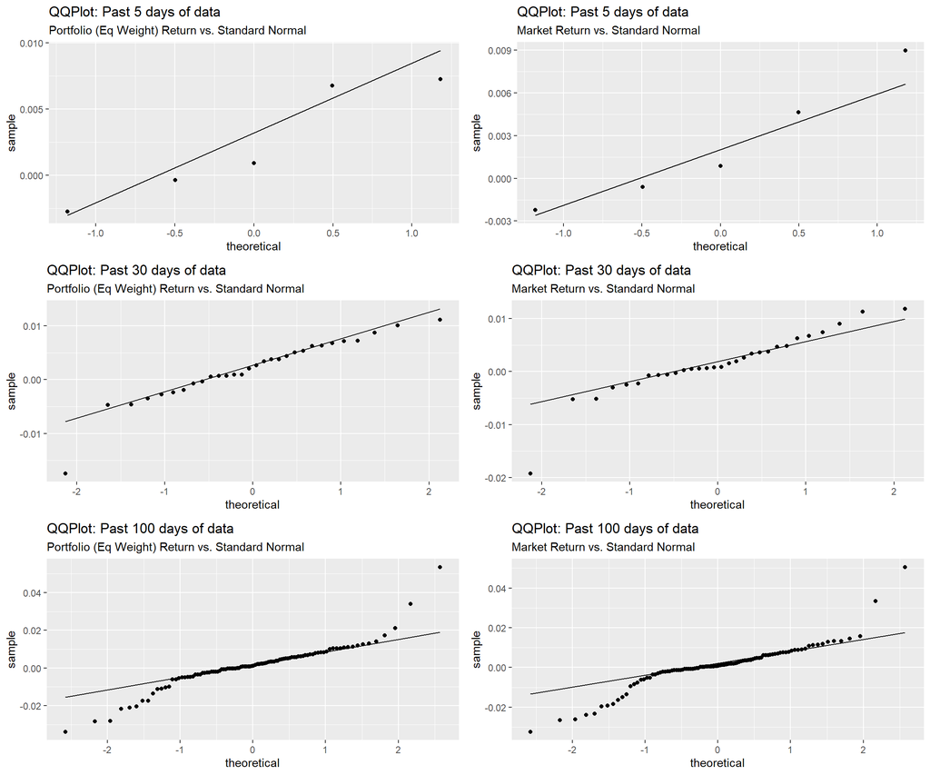

## 3.3 GGPlot

For original data, we can do the following. Let us use *ggplot* to present data with stocks on the x-axis and some defined metric on the y-axis while labeling colors using three different categories.

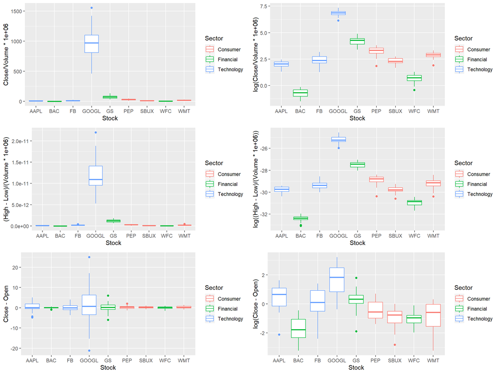

We can construct classical Cleveland dot plot to visualize the processed data. For each attribute, we can take advantage of so that it can add values to our plots. For example, the x-axis is return and the y-axis is the name of each stock while the color represents each sector.

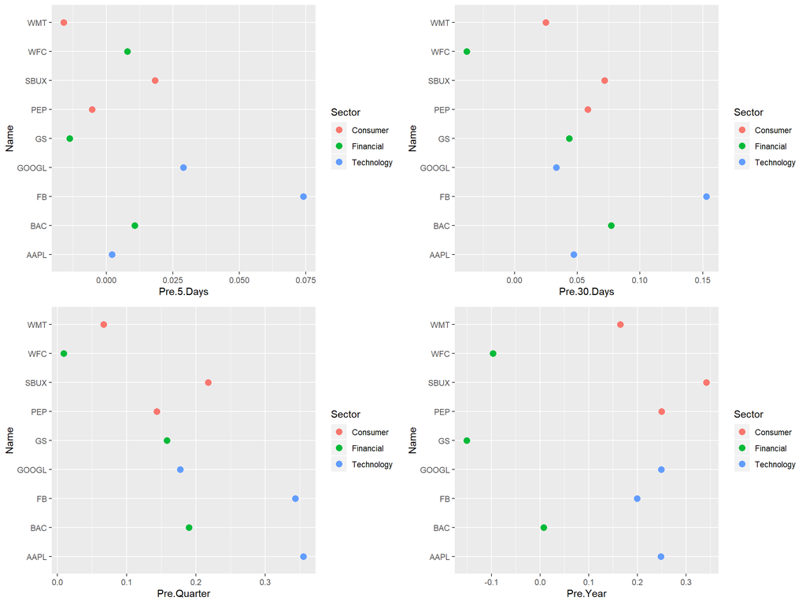

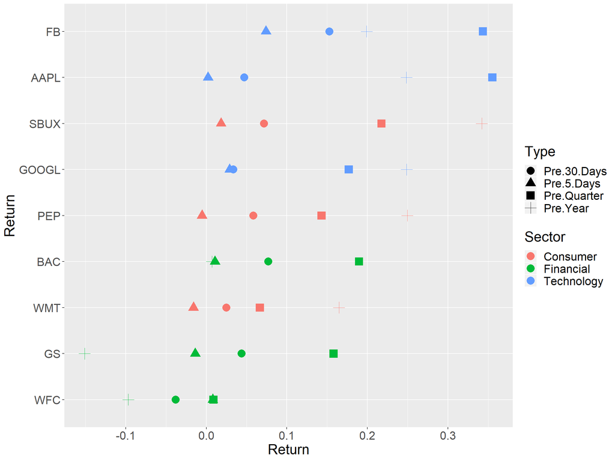

In situation when managers desire to follow sectors, one can plot returns for stocks according its sectors. By rearranging the plots, we are able to observe the following. We can facet according to 5-day returns, 30-day returns, quarterly returns, and yearly returns. Then we plot three sectors on y-axis and label stocks in different colors.

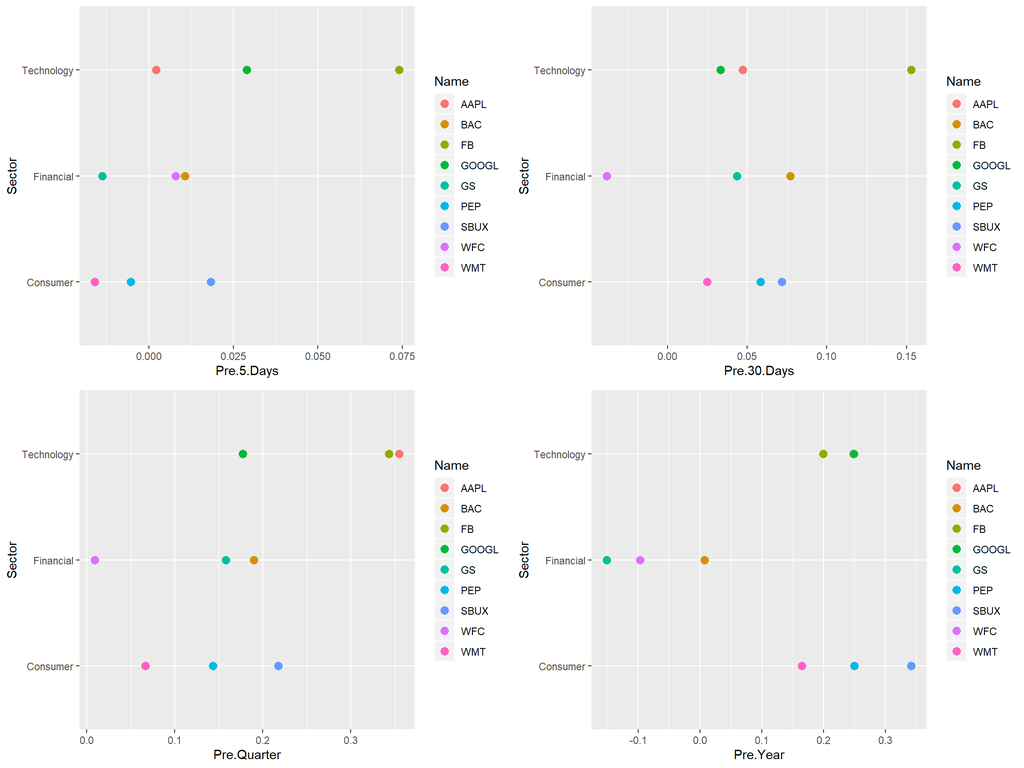

As an additional feature, we can also flip the axis to put names on x-axis and returns on y-axis while facet using types of returns. We can use color to represent Sector.

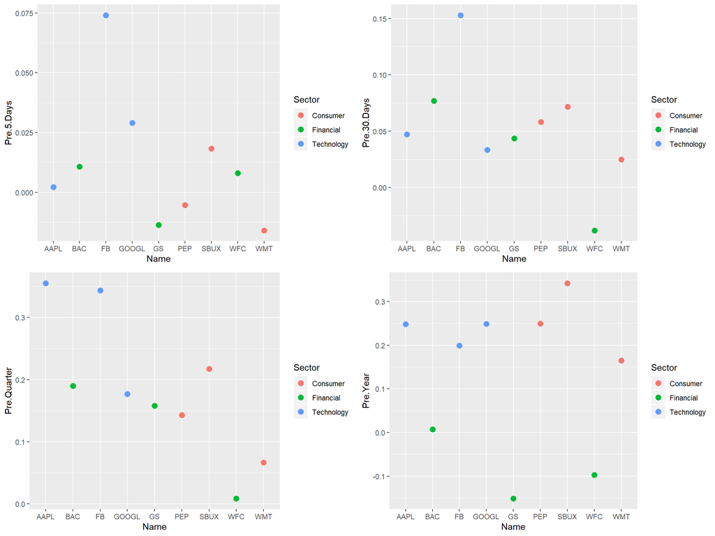

## 3.4 Parcoords

To click and drag along an axis to filter data, we are able to filter different stocks given different windows of thresholds according to different axis. This flexibility comes in handy when hedge fund managers want to select a few stocks that satisfy their strategies.

On a side note, one famous strategy is long-run reversal. This strategy selects stocks with the lowest yearly return and highest 5-day return as a portfolio. One can drag and click to create windows in the following *parcoords* output.

[interactive chart not shown]

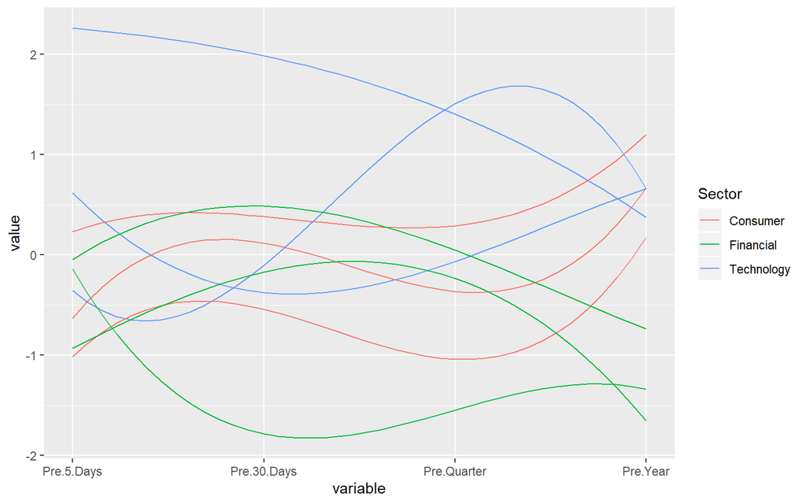

## 3.5 3D Bar Plot

By using *cloud()* function, the algorithm for identifying which edges of the bounding box should be drawn before the points are plotted fails in some cases. This school of thought presents data using three-dimensional bar plots. The z-axis represents return in numerical values. The x-axis and y-axis are stocks and type (past week, month, quarter, or year). There are three plots while each represents a sector.

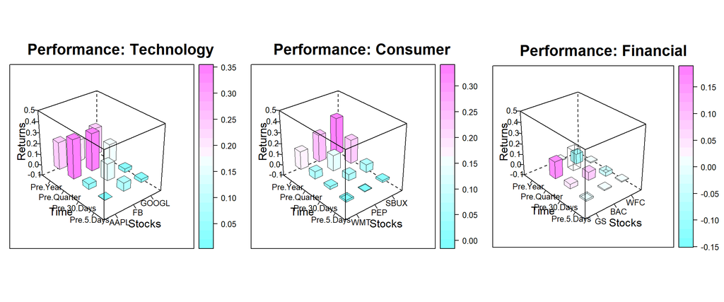

# 4 Interactive Component

Please visit [Explore Stock Market](https://y-yin.shinyapps.io/EXPLORE-STOCK-MARKET/) for Shiny App.

# 5 Conclusion

This notebook investigates the potential graphics that one can discover and explore before entering the quantitative analysis of stock market or so called fintech area.

- We present real world context by directly downloading data from internet live with codes to properly clean up and handle missing values.
- The notebook also provides explanations where to call or source the functions which is stored in another script for convenience and reproducibility purpose.
- Our analysis covers multidimensional aspects include but not limited to time-series plot, qq-plot, ggplot-, parcoords, and three-dimensional bar plot.
- We have at least a paragraph of explanation in front of a plot to explain the purpose and observation including design, forms, as well as designated metrics, for each plot.
- We wrap story up with an interactive app coded through the Shiny platform.